# Ecuaciones cuadráticas y sistemas de ecuaciones lineales.

### Datos de portada

| Nombre: | Cynthia Valeria Sánchez Vilchis |
| --- | --- |
| Matrícula: | 21020858 |
| Fecha de elaboración: | 27 Febrero 2023 |
| Nombre del módulo: | Algebra II V2 |
| Nombre del reto: | Resolviendo ecuaciones cuadráticas y sistemas de ecuaciones lineales. |
| Nombre del asesor: | Joel Garavito Navarro |

### Introducción

En este reto aplicarás los métodos de resolución de sistemas de ecuaciones lineales y cuadráticas.

**Instrucciones:** Realiza lo que se te solicita en cada paso.

### Método de eliminación por suma y resta.

Ecuación 1: $30a - 10b = 604$

Ecuación 2: $a + 5b = 65$

- Realizamos una multiplicacion a la ecuación #2, para que tenga el mismo coeficiente en b y podamos eliminar.

$$2(a + 5b = 65) \\ 2a + 10b = 130$$

- Como tenemos coeficientes iguales, podemos sumar.

$$30a - 10b = 604\\
2a + 10b = 130\\
32a = 734$$

- Despejamos a

$$32a = 734\\
a = \frac{734}{32}\\
a = \frac{367}{16}$$

- Sustituimos en la segunda ecuación.

$$\frac{367}{16} + 5b = 65\\
5b = 65 - \frac{367}{16}\\
5b = \frac{673}{16}\\
b = \frac{\frac{673}{16}}{\frac{5}{1}}\\
b = \frac{673}{80}$$

### Método gráfico.

Ecuación 1: $2x-y=-1$

Ecuación 2: $-x+y=-1$

**Solución:**

- Despejamos **y en ambas ecuaciones.**

$$y = 1 + 2x \\
y = -1 + x$$

- Se asignan valores a la variable **x en la primera ecuación.**

$$x_{0} = 1 + 2(0) = 1 = (0,1)\\
x_{2} = 1 + 2(2) = 5 = (2,5)\\
x_{4} = 1 + 2(4) = 9 = (4,9)$$

- Se asignan valores a la variable **x en la segunda ecuación.**

$$x_{0} = -1 + 0 = -1 = (0,-1)\\
x_{2} = -1 + 2 = 1 = (2,1)\\
x_{4} = -1 + 4 = 3 = (4,3)$$

**Solución y Gráfica:**

$$x = -2\\
y = -3$$

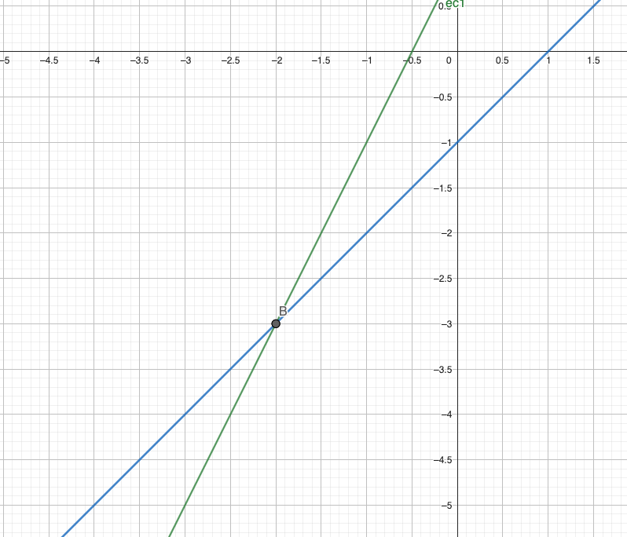

### Método de Sustitución

Ecuación 1: $1.4x+0.7y=2.8$

Ecuación 2: $-x+y=1.0$

- Despejamos la variable **y** de la segunda ecuación.

$$-x +y=1.0\\
y = 1.0 + x$$

- Sustituimos el valor de **y** en la primer ecuación.

$$1.4x+0.7y =2.8\\
1.4x+0.7(1.0+x)=2.8\\$$

- Despejamos el valor de la variable complementaria **x.**

$$1.4x+0.7+0.7x =2.8\\
2.1x+0.7=2.8\\
2.1x=2.8-0.7
x = \frac{2.1}{2.1}\\
x=1$$

- Sustituimos el valor de la variable encontrada en la ecuacion que utilizamos.

$$-x+y=1.0\\
-(1)+y=1.0\\
y =1.0+1
y = 2.0$$

**Solución:**

$$x = 1\\
y = 2$$

### Ecuaciones Cuadraticas

- Fórmula general es $x = \frac{-b+-\sqrt{b^2-4ac}}{2a}$
- Ecuación 1: $x^2-5x-14=0$

Valores de a, b y c = $a=1, b=-5, c=-14$

Aplicando la fórmula:

$$x=\frac{-(-5)+-\sqrt{-5^2-4(1)(-14)}}{2(1)}\\
x =\frac{5+-\sqrt{25+56}}{2}\\
x=\frac{5+-\sqrt{81}}{2}\\
x_{1}=\frac{5+9}{2}\\
x_{1}=\frac{14}{2}\\
x_{1}=7\\
x_{2}=\frac{5-9}{2}\\
x_{2}=\frac{-4}{2}\\
x_{2}=-2$$

**La solución es:** $x_{1}=7$ y $x2=-2$

- Ecuación 2: $3x^2-5x-2=0$

Valores de a. b y c= $a=3, b=-5, c=-2$

Aplicando la fórmula:

$$x=\frac{-(-5)+-\sqrt{-5^2-4(3)(-2)}}{2(3)}\\
x=\frac{5+-\sqrt{25+24}}{6}\\
x=\frac{5+-\sqrt{49}}{6}\\
x_{1} = \frac{5+7}{6}\\
x_{1} = \frac{12}{6}\\
x_{1} = 2\\
x_{2} = \frac{5-7}{6}\\
x_{2} = \frac{-2}{6}\\
x_{2} = \frac{-1}{3}$$

**La solución es:** $x_{1}=2$ y $x2=\frac{-1}{3}$